# week_2_sybyl

```python
# импортируем нужные библиотеки
import pandas as pd
import numpy as np
import matplotlib.pyplot as plt
import matplotlib as mpl
```

```python
# считываем агрегированные данные за май
data = pd.read_csv("taxi_16_05.csv")
```

```python
data.head()
```

|  | tpep_pickup_datetime | region | VendorID_Count | tpep_dropoff_datetime_Count | passenger_count_Count | trip_distance_Count | pickup_longitude_Count | pickup_latitude_Count | RatecodeID_Count | store_and_fwd_flag_Count | dropoff_longitude_Count | dropoff_latitude_Count | payment_type_Count | fare_amount_Count | extra_Count | mta_tax_Count | tip_amount_Count | tolls_amount_Count | improvement_surcharge_Count | total_amount_Count |
| --- | --- | --- | --- | --- | --- | --- | --- | --- | --- | --- | --- | --- | --- | --- | --- | --- | --- | --- | --- | --- |
| 0 | 2016-05-01 00:00:00 | 1015 | 1 | 1 | 1 | 1 | 1 | 1 | 1 | 1 | 1 | 1 | 1 | 1 | 1 | 1 | 1 | 1 | 1 | 1 |
| 1 | 2016-05-01 00:00:00 | 1017 | 1 | 1 | 1 | 1 | 1 | 1 | 1 | 1 | 1 | 1 | 1 | 1 | 1 | 1 | 1 | 1 | 1 | 1 |
| 2 | 2016-05-01 00:00:00 | 1029 | 3 | 3 | 3 | 3 | 3 | 3 | 3 | 3 | 3 | 3 | 3 | 3 | 3 | 3 | 3 | 3 | 3 | 3 |
| 3 | 2016-05-01 00:00:00 | 1030 | 1 | 1 | 1 | 1 | 1 | 1 | 1 | 1 | 1 | 1 | 1 | 1 | 1 | 1 | 1 | 1 | 1 | 1 |
| 4 | 2016-05-01 00:00:00 | 1033 | 4 | 4 | 4 | 4 | 4 | 4 | 4 | 4 | 4 | 4 | 4 | 4 | 4 | 4 | 4 | 4 | 4 | 4 |

### 1. Загрузите агрегированные данные о поездках в мае 2016. Просуммируйте общее количество поездок такси из каждой географической зоны и посчитайте количество ячеек, из которых в мае не было совершено ни одной поездки.

```python
# группируем данные по регионам, что бы узнать
data_1 = data.groupby(["region"]).sum()
```

```python
# узнаем количество регионов с поездками. Большая часть не вошла, поскольку в первой неделе разбивали только реальные поездки,
# а Нью-Йорк разбит на 2500 регионов, и многие имеют реки, озера, парки, здания и т.д.,
2500-len(data_1.VendorID_Count)
```

```
1283
```

### Итого 1283! Это то количество ячеек, в которых не было ни одной поездки в мае.

### 2. Нарисуйте статическую карту Нью-Йорка. Поставьте на карте точку там, где находится Эмпайр-Стейт-Билдинг.

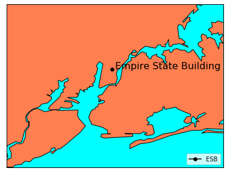

```python
# рисуем статическую карту Нью-йорка
from mpl_toolkits.basemap import Basemap
import matplotlib.pyplot as plt
plt.figure(figsize=(17,5))
map = Basemap(llcrnrlon=-74.25559,llcrnrlat=40.49612,urcrnrlon=-73.70001,urcrnrlat=40.91553, resolution = 'h')

map.drawmapboundary(fill_color='aqua')
#Fill the continents with the land color
map.fillcontinents(color='coral',lake_color='aqua')
map.drawcoastlines()

# ставим точку, где находиться Эмпайр-Стейт-Билдинг
x, y = -73.985428, 40.748817
x_1, y_1 = map(x,y)
map.plot(x_1, y_1, marker='.',color='k', markersize = 11,label = "ESB")
plt.text(x_1, y_1, ' Empire State Building', fontsize=16);
plt.legend()
plt.show()
```

### 3. Поверх статической карты Нью-Йорка визуализируйте данные о поездках из каждой ячейки так, чтобы цветовая шкала, в которую вы окрашиваете каждую ячейку, показывала суммарное количество поездок такси из неё.

### Простите, дорогие проверяющие, но с сеткой на статическую карту вышли трудности. Так что я добавил интерактивную карту + скриншот.

```python
# импортируем координаты 2500 регионов Нью-Йорка
regions = pd.read_csv('regions.csv', sep = ";")
regions.head()
```

|  | region | west | east | south | north |
| --- | --- | --- | --- | --- | --- |
| 0 | 1 | -74.25559 | -74.244478 | 40.496120 | 40.504508 |
| 1 | 2 | -74.25559 | -74.244478 | 40.504508 | 40.512896 |
| 2 | 3 | -74.25559 | -74.244478 | 40.512896 | 40.521285 |
| 3 | 4 | -74.25559 | -74.244478 | 40.521285 | 40.529673 |
| 4 | 5 | -74.25559 | -74.244478 | 40.529673 | 40.538061 |

```python
# присоединяем к regions данные о поездках из data_1
d_2 = regions.merge(data_1, how = "left",left_on='region', right_on='region')
# выбираем только нужные колонки для карты
d_2 = d_2[['region', 'west', 'east', 'south', 'north', 'VendorID_Count']]
# заменяем пропущенные значения нулями, для корректной работы карты
d_2.VendorID_Count = d_2.VendorID_Count.fillna(0)
```

```python
d_2.head()
```

|  | region | west | east | south | north | VendorID_Count |
| --- | --- | --- | --- | --- | --- | --- |
| 0 | 1 | -74.25559 | -74.244478 | 40.496120 | 40.504508 | 0.0 |
| 1 | 2 | -74.25559 | -74.244478 | 40.504508 | 40.512896 | 0.0 |
| 2 | 3 | -74.25559 | -74.244478 | 40.512896 | 40.521285 | 0.0 |
| 3 | 4 | -74.25559 | -74.244478 | 40.521285 | 40.529673 | 0.0 |
| 4 | 5 | -74.25559 | -74.244478 | 40.529673 | 40.538061 | 0.0 |

```python
# поскольку в карту нужно подавать координаты в json формате, сейчас для каждого региона сформируем не две точки, а четыре
import geojson
from geojson import Polygon, dump, Feature, FeatureCollection
i = 0
features = []
for i in range(len(d_2.west)):
    my_point = Polygon([[(d_2.west[i], d_2.south[i]), (d_2.west[i], d_2.north[i]), (d_2.east[i], d_2.north[i]), (d_2.east[i], d_2.south[i])]])
    #features.append(Feature(geometry=my_point))
    my_feature = Feature(geometry=my_point)
    my_feature.id = int( d_2.region[i] )
    features.append(my_feature)

feature_collection = FeatureCollection(features)

with open('regions.geojson', 'w') as f:
   dump(feature_collection, f)
```

```python
import folium

bins = list(d_2.VendorID_Count.quantile([0.1, 0.2, 0.3, 0.4, 0.5, 0.6, 0.7, 0.8, 0.9, 1]))

m = folium.Map(location=[lat, lon])

folium.Choropleth(
    geo_data=feature_collection,
    name='choropleth',
    data=d_2,
    columns=['region', 'VendorID_Count'],
    key_on='feature.id',
    fill_color= 'OrRd',
    fill_opacity=0.4,
    line_opacity=0.1,
    bins = bins,
    legend_name='May trips count'
).add_to(m)


folium.LayerControl().add_to(m)
```

```python
m
```

[interactive chart not shown]

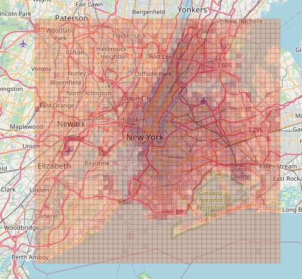

```python
from IPython.display import Image
Image(filename="Screenshot_3.jpg")
```

### 4. Вставьте интерактивную карту Нью-Йорка — такую, которую можно прокручивать и увеличивать. Поставьте метку там, где находится статуя свободы.

```python
# посчитаем середину координат для отображения
lon=(-74.25559 - 73.70001)/2
lat=(40.49612 + 40.91553)/2
```

```python
import folium

m = folium.Map(location=[lat, lon])

folium.GeoJson(
    my_point,
    name='geojson'
).add_to(m)

tooltip = 'Click me!'
folium.Marker([40.689167, -74.044583], popup='<i>Statue of Liberty</i>', tooltip=tooltip).add_to(m)
folium.LayerControl().add_to(m)
```

```
<folium.map.LayerControl at 0x27eb7d62e08>
```

```python
m
```

[interactive chart not shown]

```python
m.save('index_4.html')
m.save("filename.png")
```

### 5. Нарисуйте на интерактивной карте Нью-Йорка ячейки так, чтобы их цвет показывал среднее за месяц количество поездок такси в час из этой зоны.

```python
# группируем данные по регионам, что бы узнать
#data_1 = data.groupby(["region"]).mean()
# присоединяем к regions данные о поездках из data_1
#d_5 = regions.merge(data_1, how = "left",left_on='region', right_on='region')
# выбираем только нужные колонки для карты
#d_5 = d_5[['region', 'west', 'east', 'south', 'north', 'VendorID_Count']]
d_5 = d_2
d_5.VendorID_Count = d_5.VendorID_Count/(31*24)
# заменяем пропущенные значения нулями, для корректной работы карты
#d_5.VendorID_Count = d_5.VendorID_Count.fillna(0)
```

```python
d_5.VendorID_Count.max()
```

```
858.6008064516129
```

```python
import folium

bins = list(d_5.VendorID_Count.quantile([0.1, 0.2, 0.3, 0.4, 0.5, 0.6, 0.7, 0.8, 0.9, 1]))

m = folium.Map(location=[lat, lon])

folium.Choropleth(
    geo_data=feature_collection,
    name='choropleth',
    data = d_5,
    columns=['region', 'VendorID_Count'],
    key_on='feature.id',
    fill_color= 'OrRd',
    fill_opacity=0.4,
    line_opacity=0.1,
    bins = bins,
    nan_fill_opacity=0,
    legend_name='May trips mean'
).add_to(m)


folium.LayerControl().add_to(m)
```

```
<folium.map.LayerControl at 0x27eba977bc8>
```

```python
m
```

[interactive chart not shown]

### 6. Чтобы не выбирать из всех 2500 ячеек вручную, отфильтруйте ячейки, из которых в мае совершается в среднем меньше 5 поездок в час. Посчитайте количество оставшихся. Проверьте на карте, что среди этих ячеек нет таких, из которых поездки на самом деле невозможны.

```python
d_6 = d_5[d_5.VendorID_Count >= 5]
d_6.shape
```

```
(102, 6)
```

### 102 ячейки осталось, в которых в среднем больше 5 поездок

```python
import folium

bins = list(d_6.VendorID_Count.quantile([0, 0.25, 0.5, 0.75, 1]))

m = folium.Map(location=[lat, lon])

folium.Choropleth(
    geo_data=feature_collection,
    name='choropleth',
    data = d_6,
    columns=['region', 'VendorID_Count'],
    key_on='feature.id',
    fill_color= 'OrRd',
    fill_opacity=0.4,
    line_opacity=0.1,
    bins = bins,
    nan_fill_opacity=0,
    legend_name='May trips count'
).add_to(m)


folium.LayerControl().add_to(m)
```

```
<folium.map.LayerControl at 0x27eba8e1388>
```

```python
m
```

[interactive chart not shown]

### 7. Сохраните ноутбук в формате html, запакуйте ipynb и html в один архив и загрузите его в форму (html облегчит задачу проверки вашим рецензентам — в ipynb динамические карты часто не сохраняются, а для выполнения кода рецензентам придётся устанавливать все библиотеки).

Как видим, все ячейки закрашены адекватно, из них всех могут совершаться поездки